# EXAMEN

Camila Carrasco

29 de abril 2022

# Librería necesaria

```r
#install.packages("readxl")
library("ggpubr")
```

```r
library("ggplot2")
library("corrplot")
library("dplyr")
```

## Se cargan los datos

```r
salud <- read.csv("C:/Users/56936/Downloads/salud.csv")
```

## Realizamos una revision de nuestro dataset

```r
str(salud)
```

```
## 'data.frame':    319795 obs. of  18 variables:
##  $ HeartDisease    : chr  "No" "No" "No" "No" ...
##  $ BMI             : num  16.6 20.3 26.6 24.2 23.7 ...
##  $ Smoking         : chr  "Yes" "No" "Yes" "No" ...
##  $ AlcoholDrinking : chr  "No" "No" "No" "No" ...
##  $ Stroke          : chr  "No" "Yes" "No" "No" ...
##  $ PhysicalHealth  : num  3 0 20 0 28 6 15 5 0 0 ...
##  $ MentalHealth    : num  30 0 30 0 0 0 0 0 0 0 ...
##  $ DiffWalking     : chr  "No" "No" "No" "No" ...
##  $ Sex             : chr  "Female" "Female" "Male" "Female" ...
##  $ AgeCategory     : chr  "55-59" "80 or older" "65-69" "75-79" ...
##  $ Race            : chr  "White" "White" "White" "White" ...
##  $ Diabetic        : chr  "Yes" "No" "Yes" "No" ...
##  $ PhysicalActivity: chr  "Yes" "Yes" "Yes" "No" ...
##  $ GenHealth       : chr  "Very good" "Very good" "Fair" "Good" ...
##  $ SleepTime       : num  5 7 8 6 8 12 4 9 5 10 ...
##  $ Asthma          : chr  "Yes" "No" "Yes" "No" ...
##  $ KidneyDisease   : chr  "No" "No" "No" "No" ...
##  $ SkinCancer      : chr  "Yes" "No" "No" "Yes" ...
```

##Cambio de nombre de variables

```r
salud <- rename(salud,ENF_CORAZ="HeartDisease", IMC="BMI",FUMA="Smoking",ALCOHOL="AlcoholDrinking",ACCI_CEREBRO="Stroke",DEFICIT_SALUDFISICA="PhysicalHealth",DEFICIT_SALUDMENTAL="MentalHealth",DIFFCAMINAR="DiffWalking",SEXO="Sex",EDAD_CAT="AgeCategory",RAZA="Race",DIABETICO="Diabetic",ACT_FISICA="PhysicalActivity",SALUD_GEN="GenHealth",TIEMPO_SUE="SleepTime",ASMA="Asthma",NEFROPATIA="KidneyDisease",CANCER_PIEL="SkinCancer",)
```

*Mostraremos la caracteristicas de la base de datos*

```r
salud$ENF_CORAZ <- as.factor(salud$ENF_CORAZ)
salud$FUMA <- as.factor(salud$FUMA)
salud$ALCOHOL <- as.factor(salud$ALCOHOL)
salud$ACCI_CEREBRO <- as.factor(salud$ACCI_CEREBRO)
salud$DIFFCAMINAR <- as.factor(salud$DIFFCAMINAR)
salud$SEXO <- as.factor(salud$SEXO)
salud$RAZA <- as.factor(salud$RAZA)
salud$DIABETICO <- as.factor(salud$DIABETICO)
salud$ACT_FISICA <- as.factor(salud$ACT_FISICA)
salud$ACT_FISICA <- as.factor(salud$ACT_FISICA)
salud$SALUD_GEN <- as.factor(salud$SALUD_GEN)
salud$ASMA <- as.factor(salud$ASMA)
salud$NEFROPATIA<- as.factor(salud$NEFROPATIA)
salud$CANCER_PIEL<- as.factor(salud$CANCER_PIEL)
str(salud)
```

```
## 'data.frame':    319795 obs. of  18 variables:
##  $ ENF_CORAZ          : Factor w/ 2 levels "No","Yes": 1 1 1 1 1 2 1 1 1 1 ...
##  $ IMC                : num  16.6 20.3 26.6 24.2 23.7 ...
##  $ FUMA               : Factor w/ 2 levels "No","Yes": 2 1 2 1 1 2 1 2 1 1 ...
##  $ ALCOHOL            : Factor w/ 2 levels "No","Yes": 1 1 1 1 1 1 1 1 1 1 ...
##  $ ACCI_CEREBRO       : Factor w/ 2 levels "No","Yes": 1 2 1 1 1 1 1 1 1 1 ...
##  $ DEFICIT_SALUDFISICA: num  3 0 20 0 28 6 15 5 0 0 ...
##  $ DEFICIT_SALUDMENTAL: num  30 0 30 0 0 0 0 0 0 0 ...
##  $ DIFFCAMINAR        : Factor w/ 2 levels "No","Yes": 1 1 1 1 2 2 1 2 1 2 ...
##  $ SEXO               : Factor w/ 2 levels "Female","Male": 1 1 2 1 1 1 1 1 1 2 ...
##  $ EDAD_CAT           : chr  "55-59" "80 or older" "65-69" "75-79" ...
##  $ RAZA               : Factor w/ 6 levels "American Indian/Alaskan Native",..: 6 6 6 6 6 3 6 6 6 6 ...
##  $ DIABETICO          : Factor w/ 4 levels "No","No, borderline diabetes",..: 3 1 3 1 1 1 1 3 2 1 ...
##  $ ACT_FISICA         : Factor w/ 2 levels "No","Yes": 2 2 2 1 2 1 2 1 1 2 ...
##  $ SALUD_GEN          : Factor w/ 5 levels "Excellent","Fair",..: 5 5 2 3 5 2 2 3 2 3 ...
##  $ TIEMPO_SUE         : num  5 7 8 6 8 12 4 9 5 10 ...
##  $ ASMA               : Factor w/ 2 levels "No","Yes": 2 1 2 1 1 1 2 2 1 1 ...
##  $ NEFROPATIA         : Factor w/ 2 levels "No","Yes": 1 1 1 1 1 1 1 1 2 1 ...
##  $ CANCER_PIEL        : Factor w/ 2 levels "No","Yes": 2 1 1 2 1 1 2 1 1 1 ...
```

**Se verifica que las variables son numericas y la funcion summary indica que no existen na en la base de datos**

```r
summary(salud$DEFICIT_SALUDFISICA)
```

```
##    Min. 1st Qu.  Median    Mean 3rd Qu.    Max.
##   0.000   0.000   0.000   3.372   2.000  30.000
```

```r
summary(salud$TIEMPO_SUE)
```

```
##    Min. 1st Qu.  Median    Mean 3rd Qu.    Max.
##   1.000   6.000   7.000   7.097   8.000  24.000
```

*Confirmamos nuevamente que no existan na, nan e infinite en nuestras variables a utilizar*

```r
salud_na<-salud[is.na(salud$DEFICIT_SALUDFISICA)==TRUE,]
salud_nan<-salud[is.nan(salud$DEFICIT_SALUDFISICA)==TRUE,]
salud_infinite<-salud[is.infinite(salud$DEFICIT_SALUDFISICA)==TRUE,]

salud_na2<-salud[is.na(salud$TIEMPO_SUE)==TRUE,]
salud_nan2<-salud[is.nan(salud$TIEMPO_SUE)==TRUE,]
salud_infinite2<-salud[is.infinite(salud$TIEMPO_SUE)==TRUE,]
```

*Se confirma que no hay datos na, ni datos nulos*

*Debido a que la funcion summary no entrega la moda, la calculamos con nuestra funcion para ambas variables*

```r
mode_tiemposueno <- function(x) {
   return(as.numeric(names(which.max(table(salud$TIEMPO_SUE)))))
}

mode_deficitsaludfis<- function(x) {
   return(as.numeric(names(which.max(table(salud$DEFICIT_SALUDFISICA)))))
}

mode_tiemposueno(salud$TIEMPO_SUE)
```

```
## [1] 7
```

```r
mode_deficitsaludfis(salud$DEFICIT_SALUDFISICA)
```

```
## [1] 0
```

#Veremos de manera grafica ahora nuestras variables de interes #HISTOGRAMA DEFICIT DE LA SALUD FISICA

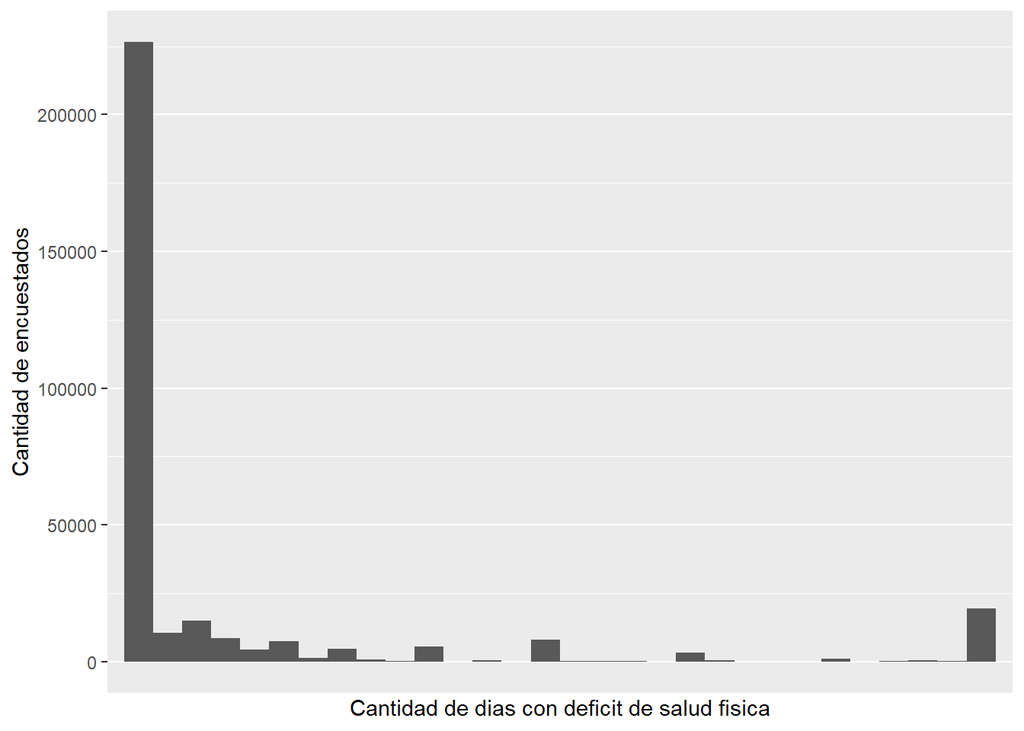

```r
ggplot(salud,aes(x = DEFICIT_SALUDFISICA))+
  geom_histogram()+
  scale_x_discrete(name = "Cantidad de dias con deficit de salud fisica")+
  scale_y_continuous(name="Cantidad de encuestados")
```

#HISTOGRAMA HORAS DE SUEÑO

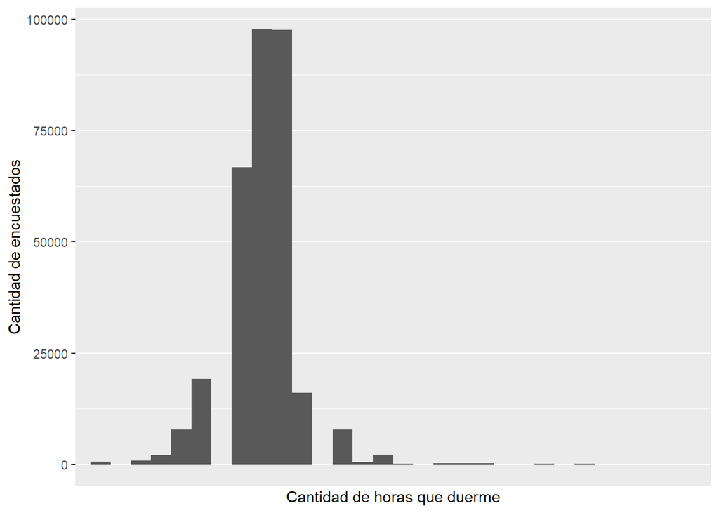

```r
ggplot(salud,aes(x = TIEMPO_SUE))+
  geom_histogram()+
  scale_x_discrete(name = "Cantidad de horas que duerme")+
  scale_y_continuous(name="Cantidad de encuestados")
```

```r
salud_new<-as.data.frame(salud[salud$TIEMPO_SUE<=20, ])
db2<-as.data.frame(salud_new[salud_new$TIEMPO_SUE>=4, ])
```

#Planteamiento hipotesis nula

H0: No existe un grado de correlación entre las horas que duerme una persona y la cantidad de días que tendrá una salud física deficiente.

*Realizamos nuestra correlacion de pearson con las variables*

```r
cor.test(db2$DEFICIT_SALUDFISICA, db2$TIEMPO_SUE, method = "pearson", na.action = na.rm)
```

```
##
##  Pearson's product-moment correlation
##
## data:  db2$DEFICIT_SALUDFISICA and db2$TIEMPO_SUE
## t = -22.133, df = 316418, p-value < 2.2e-16
## alternative hypothesis: true correlation is not equal to 0
## 95 percent confidence interval:
##  -0.04279531 -0.03583747
## sample estimates:
##         cor
## -0.03931687
```

*** Graficar la dispersión de los datos y el respectivo estadístico de pearson***

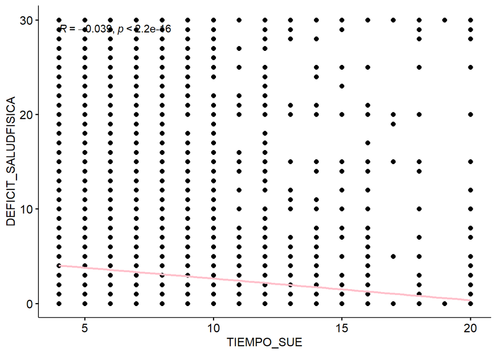

```r
sp <- ggscatter(db2, x = "TIEMPO_SUE" , y = "DEFICIT_SALUDFISICA",
                add = "reg.line",
                add.params = list(color = "pink", fill = "lightgray"),
                conf.int = FALSE # Add confidence interval
)
sp+stat_cor(method = "pearson")
```

*nuevos promedios y medianas*

```r
summary(salud_new$DEFICIT_SALUDFISICA)
```

```
##    Min. 1st Qu.  Median    Mean 3rd Qu.    Max.
##   0.000   0.000   0.000   3.371   2.000  30.000
```

```r
summary(salud_new$TIEMPO_SUE)
```

```
##    Min. 1st Qu.  Median    Mean 3rd Qu.    Max.
##   1.000   6.000   7.000   7.095   8.000  20.000
```

Las horas de sueño impactan la salud fisica, por lo que la variable dependiente es deficit salud fisica.

#Regresion 1

```r
reg1<- lm(DEFICIT_SALUDFISICA ~ TIEMPO_SUE, data = db2, na.action = na.omit)
summary(reg1)
```

```
##
## Call:
## lm(formula = DEFICIT_SALUDFISICA ~ TIEMPO_SUE, data = db2, na.action = na.omit)
##
## Residuals:
##    Min     1Q Median     3Q    Max
## -4.024 -3.335 -3.105 -1.564 29.651
##
## Coefficients:
##             Estimate Std. Error t value Pr(>|t|)
## (Intercept)  4.94213    0.07543   65.52   <2e-16 ***
## TIEMPO_SUE  -0.22965    0.01038  -22.13   <2e-16 ***
## ---
## Signif. codes:  0 '***' 0.001 '**' 0.01 '*' 0.05 '.' 0.1 ' ' 1
##
## Residual standard error: 7.852 on 316418 degrees of freedom
## Multiple R-squared:  0.001546,   Adjusted R-squared:  0.001543
## F-statistic: 489.9 on 1 and 316418 DF,  p-value: < 2.2e-16
```

*Veremos visualmente esta regresion*

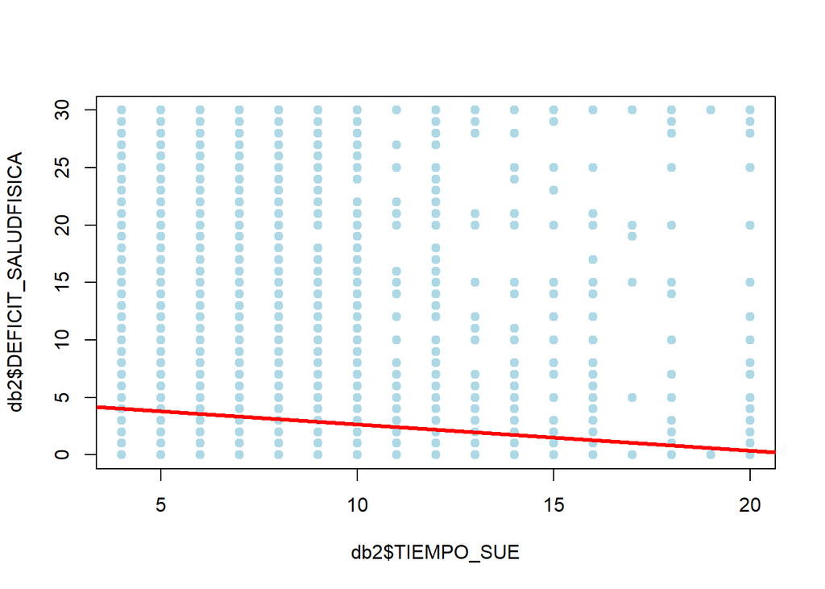

```r
plot(db2$TIEMPO_SUE, db2$DEFICIT_SALUDFISICA, pch = 19, col = "lightblue")

# Línea de regresión
abline(lm(db2$DEFICIT_SALUDFISICA ~ db2$TIEMPO_SUE), col = "red", lwd = 3)

# Correlación de Pearson
text(paste("Correlación:", round(cor(db2$TIEMPO_SUE, db2$DEFICIT_SALUDFISICA), 2)), x = 25, y = 95)
```

#regresion 2

```r
reg2<- lm(DEFICIT_SALUDFISICA ~ TIEMPO_SUE+factor(DEFICIT_SALUDMENTAL), data = db2, na.action = na.omit)
summary(reg2)
```

```
##
## Call:
## lm(formula = DEFICIT_SALUDFISICA ~ TIEMPO_SUE + factor(DEFICIT_SALUDMENTAL),
##     data = db2, na.action = na.omit)
##
## Residuals:
##     Min      1Q  Median      3Q     Max
## -11.159  -2.369  -2.307  -1.580  28.510
##
## Coefficients:
##                               Estimate Std. Error t value Pr(>|t|)
## (Intercept)                    2.74652    0.07446  36.887  < 2e-16 ***
## TIEMPO_SUE                    -0.06283    0.01003  -6.267 3.68e-10 ***
## factor(DEFICIT_SALUDMENTAL)1  -0.11487    0.08025  -1.431 0.152308
## factor(DEFICIT_SALUDMENTAL)2   0.39917    0.06125   6.517 7.18e-11 ***
## factor(DEFICIT_SALUDMENTAL)3   0.55335    0.07589   7.291 3.08e-13 ***
## factor(DEFICIT_SALUDMENTAL)4   0.65448    0.10451   6.262 3.80e-10 ***
## factor(DEFICIT_SALUDMENTAL)5   1.34976    0.06584  20.500  < 2e-16 ***
## factor(DEFICIT_SALUDMENTAL)6   1.59585    0.19619   8.134 4.16e-16 ***
## factor(DEFICIT_SALUDMENTAL)7   1.05041    0.10329  10.169  < 2e-16 ***
## factor(DEFICIT_SALUDMENTAL)8   1.55752    0.23026   6.764 1.34e-11 ***
## factor(DEFICIT_SALUDMENTAL)9   2.63920    0.53343   4.948 7.52e-07 ***
## factor(DEFICIT_SALUDMENTAL)10  2.78272    0.07588  36.672  < 2e-16 ***
## factor(DEFICIT_SALUDMENTAL)11  3.29950    0.84317   3.913 9.11e-05 ***
## factor(DEFICIT_SALUDMENTAL)12  2.74208    0.27659   9.914  < 2e-16 ***
## factor(DEFICIT_SALUDMENTAL)13  3.42862    0.72913   4.702 2.57e-06 ***
## factor(DEFICIT_SALUDMENTAL)14  3.44125    0.16884  20.381  < 2e-16 ***
## factor(DEFICIT_SALUDMENTAL)15  4.19862    0.07833  53.604  < 2e-16 ***
## factor(DEFICIT_SALUDMENTAL)16  6.03565    0.62004   9.734  < 2e-16 ***
## factor(DEFICIT_SALUDMENTAL)17  4.67610    0.67733   6.904 5.08e-12 ***
## factor(DEFICIT_SALUDMENTAL)18  4.11115    0.52310   7.859 3.88e-15 ***
## factor(DEFICIT_SALUDMENTAL)19  6.17129    1.68610   3.660 0.000252 ***
## factor(DEFICIT_SALUDMENTAL)20  5.23653    0.10472  50.003  < 2e-16 ***
## factor(DEFICIT_SALUDMENTAL)21  5.30336    0.40868  12.977  < 2e-16 ***
## factor(DEFICIT_SALUDMENTAL)22  6.54594    0.76185   8.592  < 2e-16 ***
## factor(DEFICIT_SALUDMENTAL)23  4.70464    0.93541   5.029 4.92e-07 ***
## factor(DEFICIT_SALUDMENTAL)24  5.45092    0.93539   5.827 5.63e-09 ***
## factor(DEFICIT_SALUDMENTAL)25  5.87926    0.17315  33.954  < 2e-16 ***
## factor(DEFICIT_SALUDMENTAL)26  8.34452    0.99885   8.354  < 2e-16 ***
## factor(DEFICIT_SALUDMENTAL)27  5.15129    0.68570   7.512 5.82e-14 ***
## factor(DEFICIT_SALUDMENTAL)28  5.57052    0.34002  16.383  < 2e-16 ***
## factor(DEFICIT_SALUDMENTAL)29  6.75739    0.43067  15.690  < 2e-16 ***
## factor(DEFICIT_SALUDMENTAL)30  8.66333    0.06109 141.804  < 2e-16 ***
## ---
## Signif. codes:  0 '***' 0.001 '**' 0.01 '*' 0.05 '.' 0.1 ' ' 1
##
## Residual standard error: 7.54 on 316388 degrees of freedom
## Multiple R-squared:  0.07931,    Adjusted R-squared:  0.07922
## F-statistic: 879.2 on 31 and 316388 DF,  p-value: < 2.2e-16
```

#regresion 3

```r
reg3<- lm(DEFICIT_SALUDFISICA ~ TIEMPO_SUE+factor(ENF_CORAZ)+factor(ACCI_CEREBRO)+factor(DIABETICO)+factor(ASMA)+factor(NEFROPATIA)+factor(CANCER_PIEL), data = db2, na.action = na.omit)
summary(reg3)
```

```
##
## Call:
## lm(formula = DEFICIT_SALUDFISICA ~ TIEMPO_SUE + factor(ENF_CORAZ) +
##     factor(ACCI_CEREBRO) + factor(DIABETICO) + factor(ASMA) +
##     factor(NEFROPATIA) + factor(CANCER_PIEL), data = db2, na.action = na.omit)
##
## Residuals:
##    Min     1Q Median     3Q    Max
## -18.98  -2.60  -2.09  -1.34  31.16
##
## Coefficients:
##                                          Estimate Std. Error t value Pr(>|t|)
## (Intercept)                               3.84002    0.07326  52.413   <2e-16
## TIEMPO_SUE                               -0.25000    0.01001 -24.976   <2e-16
## factor(ENF_CORAZ)Yes                      3.16579    0.05032  62.909   <2e-16
## factor(ACCI_CEREBRO)Yes                   3.66958    0.07278  50.423   <2e-16
## factor(DIABETICO)No, borderline diabetes  1.21093    0.09353  12.947   <2e-16
## factor(DIABETICO)Yes                      2.56718    0.04165  61.634   <2e-16
## factor(DIABETICO)Yes (during pregnancy)   0.28742    0.15108   1.902   0.0571
## factor(ASMA)Yes                           2.22604    0.03970  56.070   <2e-16
## factor(NEFROPATIA)Yes                     3.99831    0.07329  54.557   <2e-16
## factor(CANCER_PIEL)Yes                    0.51012    0.04649  10.973   <2e-16
##
## (Intercept)                              ***
## TIEMPO_SUE                               ***
## factor(ENF_CORAZ)Yes                     ***
## factor(ACCI_CEREBRO)Yes                  ***
## factor(DIABETICO)No, borderline diabetes ***
## factor(DIABETICO)Yes                     ***
## factor(DIABETICO)Yes (during pregnancy)  .
## factor(ASMA)Yes                          ***
## factor(NEFROPATIA)Yes                    ***
## factor(CANCER_PIEL)Yes                   ***
## ---
## Signif. codes:  0 '***' 0.001 '**' 0.01 '*' 0.05 '.' 0.1 ' ' 1
##
## Residual standard error: 7.557 on 316410 degrees of freedom
## Multiple R-squared:  0.07502,    Adjusted R-squared:  0.07499
## F-statistic:  2851 on 9 and 316410 DF,  p-value: < 2.2e-16
```

# regresion 4

```r
reg4<- lm(DEFICIT_SALUDFISICA ~ TIEMPO_SUE+factor(DEFICIT_SALUDMENTAL)+factor(DIFFCAMINAR), data = db2, na.action = na.omit)
summary(reg4)
```

```
##
## Call:
## lm(formula = DEFICIT_SALUDFISICA ~ TIEMPO_SUE + factor(DEFICIT_SALUDMENTAL) +
##     factor(DIFFCAMINAR), data = db2, na.action = na.omit)
##
## Residuals:
##      Min       1Q   Median       3Q      Max
## -17.3086  -1.7016  -1.2677  -0.9961  29.9092
##
## Coefficients:
##                                Estimate Std. Error t value Pr(>|t|)
## (Intercept)                    1.901467   0.068273  27.851  < 2e-16 ***
## TIEMPO_SUE                    -0.090533   0.009182  -9.860  < 2e-16 ***
## factor(DEFICIT_SALUDMENTAL)1   0.042574   0.073492   0.579 0.562384
## factor(DEFICIT_SALUDMENTAL)2   0.437976   0.056092   7.808 5.82e-15 ***
## factor(DEFICIT_SALUDMENTAL)3   0.524443   0.069501   7.546 4.51e-14 ***
## factor(DEFICIT_SALUDMENTAL)4   0.634197   0.095710   6.626 3.45e-11 ***
## factor(DEFICIT_SALUDMENTAL)5   1.252219   0.060297  20.767  < 2e-16 ***
## factor(DEFICIT_SALUDMENTAL)6   1.214192   0.179672   6.758 1.40e-11 ***
## factor(DEFICIT_SALUDMENTAL)7   0.985553   0.094591  10.419  < 2e-16 ***
## factor(DEFICIT_SALUDMENTAL)8   1.256747   0.210872   5.960 2.53e-09 ***
## factor(DEFICIT_SALUDMENTAL)9   1.891370   0.488513   3.872 0.000108 ***
## factor(DEFICIT_SALUDMENTAL)10  2.347066   0.069512  33.765  < 2e-16 ***
## factor(DEFICIT_SALUDMENTAL)11  3.220079   0.772158   4.170 3.04e-05 ***
## factor(DEFICIT_SALUDMENTAL)12  2.233823   0.253304   8.819  < 2e-16 ***
## factor(DEFICIT_SALUDMENTAL)13  3.377807   0.667717   5.059 4.22e-07 ***
## factor(DEFICIT_SALUDMENTAL)14  3.032375   0.154631  19.610  < 2e-16 ***
## factor(DEFICIT_SALUDMENTAL)15  3.373303   0.071807  46.977  < 2e-16 ***
## factor(DEFICIT_SALUDMENTAL)16  4.833448   0.567839   8.512  < 2e-16 ***
## factor(DEFICIT_SALUDMENTAL)17  3.551773   0.620301   5.726 1.03e-08 ***
## factor(DEFICIT_SALUDMENTAL)18  3.167665   0.479061   6.612 3.79e-11 ***
## factor(DEFICIT_SALUDMENTAL)19  4.969317   1.544094   3.218 0.001290 **
## factor(DEFICIT_SALUDMENTAL)20  4.195241   0.095997  43.702  < 2e-16 ***
## factor(DEFICIT_SALUDMENTAL)21  4.477630   0.374278  11.963  < 2e-16 ***
## factor(DEFICIT_SALUDMENTAL)22  4.668641   0.697724   6.691 2.22e-11 ***
## factor(DEFICIT_SALUDMENTAL)23  4.217884   0.856627   4.924 8.49e-07 ***
## factor(DEFICIT_SALUDMENTAL)24  4.425156   0.856613   5.166 2.39e-07 ***
## factor(DEFICIT_SALUDMENTAL)25  4.714102   0.158641  29.716  < 2e-16 ***
## factor(DEFICIT_SALUDMENTAL)26  6.871420   0.914745   7.512 5.85e-14 ***
## factor(DEFICIT_SALUDMENTAL)27  4.333202   0.627954   6.901 5.19e-12 ***
## factor(DEFICIT_SALUDMENTAL)28  4.577856   0.311407  14.701  < 2e-16 ***
## factor(DEFICIT_SALUDMENTAL)29  5.148942   0.394449  13.054  < 2e-16 ***
## factor(DEFICIT_SALUDMENTAL)30  6.844261   0.056432 121.283  < 2e-16 ***
## factor(DIFFCAMINAR)Yes         8.925033   0.036174 246.728  < 2e-16 ***
## ---
## Signif. codes:  0 '***' 0.001 '**' 0.01 '*' 0.05 '.' 0.1 ' ' 1
##
## Residual standard error: 6.905 on 316387 degrees of freedom
## Multiple R-squared:  0.2279, Adjusted R-squared:  0.2278
## F-statistic:  2918 on 32 and 316387 DF,  p-value: < 2.2e-16
```

#regresion 5 con la totalidad de los datos

```r
reg5<- lm(DEFICIT_SALUDFISICA ~ ., data =  db2, na.action = na.omit)
summary(reg5)
```

```
##
## Call:
## lm(formula = DEFICIT_SALUDFISICA ~ ., data = db2, na.action = na.omit)
##
## Residuals:
##      Min       1Q   Median       3Q      Max
## -28.4357  -1.8240  -0.7395   0.0835  31.0013
##
## Coefficients:
##                                   Estimate Std. Error t value Pr(>|t|)
## (Intercept)                       1.492963   0.128119  11.653  < 2e-16 ***
## ENF_CORAZYes                      0.254911   0.042193   6.042 1.53e-09 ***
## IMC                              -0.016095   0.001856  -8.673  < 2e-16 ***
## FUMAYes                           0.108413   0.023165   4.680 2.87e-06 ***
## ALCOHOLYes                       -0.225403   0.043706  -5.157 2.51e-07 ***
## ACCI_CEREBROYes                   0.370669   0.059567   6.223 4.89e-10 ***
## DEFICIT_SALUDMENTAL               0.132474   0.001488  88.999  < 2e-16 ***
## DIFFCAMINARYes                    4.356239   0.037395 116.494  < 2e-16 ***
## SEXOMale                         -0.042056   0.022393  -1.878 0.060369 .
## EDAD_CAT25-29                     0.033373   0.063492   0.526 0.599150
## EDAD_CAT30-34                     0.154592   0.062110   2.489 0.012811 *
## EDAD_CAT35-39                     0.225894   0.060900   3.709 0.000208 ***
## EDAD_CAT40-44                     0.348816   0.060709   5.746 9.16e-09 ***
## EDAD_CAT45-49                     0.486599   0.060243   8.077 6.64e-16 ***
## EDAD_CAT50-54                     0.659140   0.058324  11.301  < 2e-16 ***
## EDAD_CAT55-59                     0.680547   0.056730  11.996  < 2e-16 ***
## EDAD_CAT60-64                     0.742139   0.055780  13.305  < 2e-16 ***
## EDAD_CAT65-69                     0.492628   0.056026   8.793  < 2e-16 ***
## EDAD_CAT70-74                     0.307069   0.057631   5.328 9.93e-08 ***
## EDAD_CAT75-79                     0.253146   0.062838   4.029 5.61e-05 ***
## EDAD_CAT80 or older              -0.233849   0.062259  -3.756 0.000173 ***
## RAZAAsian                        -0.383500   0.109907  -3.489 0.000484 ***
## RAZABlack                        -0.445139   0.094605  -4.705 2.54e-06 ***
## RAZAHispanic                     -0.340938   0.093283  -3.655 0.000257 ***
## RAZAOther                         0.146778   0.103749   1.415 0.157145
## RAZAWhite                         0.155715   0.086503   1.800 0.071844 .
## DIABETICONo, borderline diabetes -0.055756   0.075999  -0.734 0.463169
## DIABETICOYes                     -0.155252   0.035643  -4.356 1.33e-05 ***
## DIABETICOYes (during pregnancy)  -0.099824   0.122626  -0.814 0.415616
## ACT_FISICAYes                    -0.912737   0.027946 -32.660  < 2e-16 ***
## SALUD_GENFair                     6.706307   0.046049 145.634  < 2e-16 ***
## SALUD_GENGood                     1.184405   0.032893  36.008  < 2e-16 ***
## SALUD_GENPoor                    17.205182   0.071982 239.022  < 2e-16 ***
## SALUD_GENVery good                0.261398   0.030244   8.643  < 2e-16 ***
## TIEMPO_SUE                       -0.059624   0.008219  -7.255 4.04e-13 ***
## ASMAYes                           0.542581   0.032667  16.609  < 2e-16 ***
## NEFROPATIAYes                     0.774749   0.059842  12.947  < 2e-16 ***
## CANCER_PIELYes                    0.260680   0.039142   6.660 2.74e-11 ***
## ---
## Signif. codes:  0 '***' 0.001 '**' 0.01 '*' 0.05 '.' 0.1 ' ' 1
##
## Residual standard error: 6.103 on 316382 degrees of freedom
## Multiple R-squared:  0.3968, Adjusted R-squared:  0.3968
## F-statistic:  5626 on 37 and 316382 DF,  p-value: < 2.2e-16
```